# K-Nearest Neighbours for White Wine Classification

November 30 2017

### 1. Load the data file and required libraries;

```r
ww <- read.csv2("winequality-white.csv", stringsAsFactors = FALSE)
library(gmodels)
library(ggplot2)
library(class)
str(ww)
```

```
## 'data.frame':    4898 obs. of  12 variables:
##  $ fixed.acidity       : chr  "7" "6.3" "8.1" "7.2" ...
##  $ volatile.acidity    : chr  "0.27" "0.3" "0.28" "0.23" ...
##  $ citric.acid         : chr  "0.36" "0.34" "0.4" "0.32" ...
##  $ residual.sugar      : chr  "20.7" "1.6" "6.9" "8.5" ...
##  $ chlorides           : chr  "0.045" "0.049" "0.05" "0.058" ...
##  $ free.sulfur.dioxide : chr  "45" "14" "30" "47" ...
##  $ total.sulfur.dioxide: chr  "170" "132" "97" "186" ...
##  $ density             : chr  "1.001" "0.994" "0.9951" "0.9956" ...
##  $ pH                  : chr  "3" "3.3" "3.26" "3.19" ...
##  $ sulphates           : chr  "0.45" "0.49" "0.44" "0.4" ...
##  $ alcohol             : chr  "8.8" "9.5" "10.1" "9.9" ...
##  $ quality             : int  6 6 6 6 6 6 6 6 6 6 ...
```

#### Convert factors to numeric

```r
ww[,1] <- as.numeric(ww[,1])
ww[,2] <- as.numeric(ww[,2])
ww[,3] <- as.numeric(ww[,3])
ww[,4] <- as.numeric(ww[,4])
ww[,5] <- as.numeric(ww[,5])
ww[,6] <- as.numeric(ww[,6])
ww[,7] <- as.numeric(ww[,7])
ww[,8] <- as.numeric(ww[,8])
ww[,9] <- as.numeric(ww[,9])
ww[,10] <- as.numeric(ww[,10])
ww[,11] <- as.numeric(ww[,11])
str(ww)
```

```
## 'data.frame':    4898 obs. of  12 variables:
##  $ fixed.acidity       : num  7 6.3 8.1 7.2 7.2 8.1 6.2 7 6.3 8.1 ...
##  $ volatile.acidity    : num  0.27 0.3 0.28 0.23 0.23 0.28 0.32 0.27 0.3 0.22 ...
##  $ citric.acid         : num  0.36 0.34 0.4 0.32 0.32 0.4 0.16 0.36 0.34 0.43 ...
##  $ residual.sugar      : num  20.7 1.6 6.9 8.5 8.5 6.9 7 20.7 1.6 1.5 ...
##  $ chlorides           : num  0.045 0.049 0.05 0.058 0.058 0.05 0.045 0.045 0.049 0.044 ...
##  $ free.sulfur.dioxide : num  45 14 30 47 47 30 30 45 14 28 ...
##  $ total.sulfur.dioxide: num  170 132 97 186 186 97 136 170 132 129 ...
##  $ density             : num  1.001 0.994 0.995 0.996 0.996 ...
##  $ pH                  : num  3 3.3 3.26 3.19 3.19 3.26 3.18 3 3.3 3.22 ...
##  $ sulphates           : num  0.45 0.49 0.44 0.4 0.4 0.44 0.47 0.45 0.49 0.45 ...
##  $ alcohol             : num  8.8 9.5 10.1 9.9 9.9 10.1 9.6 8.8 9.5 11 ...
##  $ quality             : int  6 6 6 6 6 6 6 6 6 6 ...
```

### 2. construct a new binary column “good wine” that indicates whether the wine is good (which we define as having a quality of 6 or higher) or not;

```r
ww$good.wine <- 1
ww$good.wine[ww$quality < 6] = 0
```

### 3. Split the data set into a training data set (~40%), a validation data set (~30%) and a test data set (~30%) — make sure to shuffle the record before the split;

```r
# Set seed to maintain same shuffle order each time code is run
set.seed(7)

# Set ratios so can easily change the number of observations in each set if needed
split.ratios = c(train = .4, validate = .3, test = .3)

# Shuffle original dataset
ww.shuffled <- ww[sample.int(nrow(ww)),]

# Set indices for each subset of data and split original dataset into required subsets
train.indices <- ceiling(split.ratios[[1]]*nrow(ww.shuffled))
ww.train <- ww.shuffled[1:train.indices,]

validate.indices <- train.indices + floor(split.ratios[[2]]*nrow(ww.shuffled))
ww.validate <- ww.shuffled[(train.indices + 1):validate.indices,]

test.indices <- validate.indices + 1
ww.test <- ww.shuffled[test.indices:nrow(ww.shuffled),]

# Final datasets to use are ww.train, ww.validate, and ww.test
```

### 4. Normalise the data according to the Z-score transform;

```r
standardized.train <- ww.train[,-12:-13]
mean.1 <- mean(ww.train[,1])
std.1 <- sd(ww.train[,1])
standardized.train[,1] <- (ww.train[,1] - mean.1) / std.1

mean.2 <- mean(ww.train[,2])
std.2 <- sd(ww.train[,2])
standardized.train[,2] <- (ww.train[,2] - mean.2) / std.2

mean.3 <- mean(ww.train[,3])
std.3 <- sd(ww.train[,3])
standardized.train[,3] <- (ww.train[,3] - mean.3) / std.3

mean.4 <- mean(ww.train[,4])
std.4 <- sd(ww.train[,4])
standardized.train[,4] <- (ww.train[,4] - mean.4) / std.4

mean.5 <- mean(ww.train[,5])
std.5 <- sd(ww.train[,5])
standardized.train[,5] <- (ww.train[,5] - mean.5) / std.5

mean.6 <- mean(ww.train[,6])
std.6 <- sd(ww.train[,6])
standardized.train[,6] <- (ww.train[,6] - mean.6) / std.6

mean.7 <- mean(ww.train[,7])
std.7 <- sd(ww.train[,7])
standardized.train[,7] <- (ww.train[,7] - mean.7) / std.7

mean.8 <- mean(ww.train[,8])
std.8 <- sd(ww.train[,8])
standardized.train[,8] <- (ww.train[,8] - mean.8) / std.8

mean.9 <- mean(ww.train[,9])
std.9 <- sd(ww.train[,9])
standardized.train[,9] <- (ww.train[,9] - mean.9) / std.9

mean.10 <- mean(ww.train[,10])
std.10 <- sd(ww.train[,10])
standardized.train[,10] <- (ww.train[,10] - mean.10) / std.10

mean.11 <- mean(ww.train[,11])
std.11 <- sd(ww.train[,11])
standardized.train[,11] <- (ww.train[,11] - mean.11) / std.11
```

```r
standardized.validate <- ww.validate[,-12:-13]
mean.1 <- mean(ww.validate[,1])
std.1 <- sd(ww.validate[,1])
standardized.validate[,1] <- (ww.validate[,1] - mean.1) / std.1

mean.2 <- mean(ww.validate[,2])
std.2 <- sd(ww.validate[,2])
standardized.validate[,2] <- (ww.validate[,2] - mean.2) / std.2

mean.3 <- mean(ww.validate[,3])
std.3 <- sd(ww.validate[,3])
standardized.validate[,3] <- (ww.validate[,3] - mean.3) / std.3

mean.4 <- mean(ww.validate[,4])
std.4 <- sd(ww.validate[,4])
standardized.validate[,4] <- (ww.validate[,4] - mean.4) / std.4

mean.5 <- mean(ww.validate[,5])
std.5 <- sd(ww.validate[,5])
standardized.validate[,5] <- (ww.validate[,5] - mean.5) / std.5

mean.6 <- mean(ww.validate[,6])
std.6 <- sd(ww.validate[,6])
standardized.validate[,6] <- (ww.validate[,6] - mean.6) / std.6

mean.7 <- mean(ww.validate[,7])
std.7 <- sd(ww.validate[,7])
standardized.validate[,7] <- (ww.validate[,7] - mean.7) / std.7

mean.8 <- mean(ww.validate[,8])
std.8 <- sd(ww.validate[,8])
standardized.validate[,8] <- (ww.validate[,8] - mean.8) / std.8

mean.9 <- mean(ww.validate[,9])
std.9 <- sd(ww.validate[,9])
standardized.validate[,9] <- (ww.validate[,9] - mean.9) / std.9

mean.10 <- mean(ww.validate[,10])
std.10 <- sd(ww.validate[,10])
standardized.validate[,10] <- (ww.validate[,10] - mean.10) / std.10

mean.11 <- mean(ww.validate[,11])
std.11 <- sd(ww.validate[,11])
standardized.validate[,11] <- (ww.validate[,11] - mean.11) / std.11
```

```r
standardized.test <- ww.test[,-12:-13]
mean.1 <- mean(ww.test[,1])
std.1 <- sd(ww.test[,1])
standardized.test[,1] <- (ww.test[,1] - mean.1) / std.1

mean.2 <- mean(ww.test[,2])
std.2 <- sd(ww.test[,2])
standardized.test[,2] <- (ww.test[,2] - mean.2) / std.2

mean.3 <- mean(ww.test[,3])
std.3 <- sd(ww.test[,3])
standardized.test[,3] <- (ww.test[,3] - mean.3) / std.3

mean.4 <- mean(ww.test[,4])
std.4 <- sd(ww.test[,4])
standardized.test[,4] <- (ww.test[,4] - mean.4) / std.4

mean.5 <- mean(ww.test[,5])
std.5 <- sd(ww.test[,5])
standardized.test[,5] <- (ww.test[,5] - mean.5) / std.5

mean.6 <- mean(ww.test[,6])
std.6 <- sd(ww.test[,6])
standardized.test[,6] <- (ww.test[,6] - mean.6) / std.6

mean.7 <- mean(ww.test[,7])
std.7 <- sd(ww.test[,7])
standardized.test[,7] <- (ww.test[,7] - mean.7) / std.7

mean.8 <- mean(ww.test[,8])
std.8 <- sd(ww.test[,8])
standardized.test[,8] <- (ww.test[,8] - mean.8) / std.8

mean.9 <- mean(ww.test[,9])
std.9 <- sd(ww.test[,9])
standardized.test[,9] <- (ww.test[,9] - mean.9) / std.9

mean.10 <- mean(ww.test[,10])
std.10 <- sd(ww.test[,10])
standardized.test[,10] <- (ww.test[,10] - mean.10) / std.10

mean.11 <- mean(ww.test[,11])
std.11 <- sd(ww.test[,11])
standardized.test[,11] <- (ww.test[,11] - mean.11) / std.11
```

```r
standardized.ww <- rbind(standardized.train, standardized.validate)
```

### 5. Load and train the k-Nearest Neighbours classifiers for k = 1, .., 80;

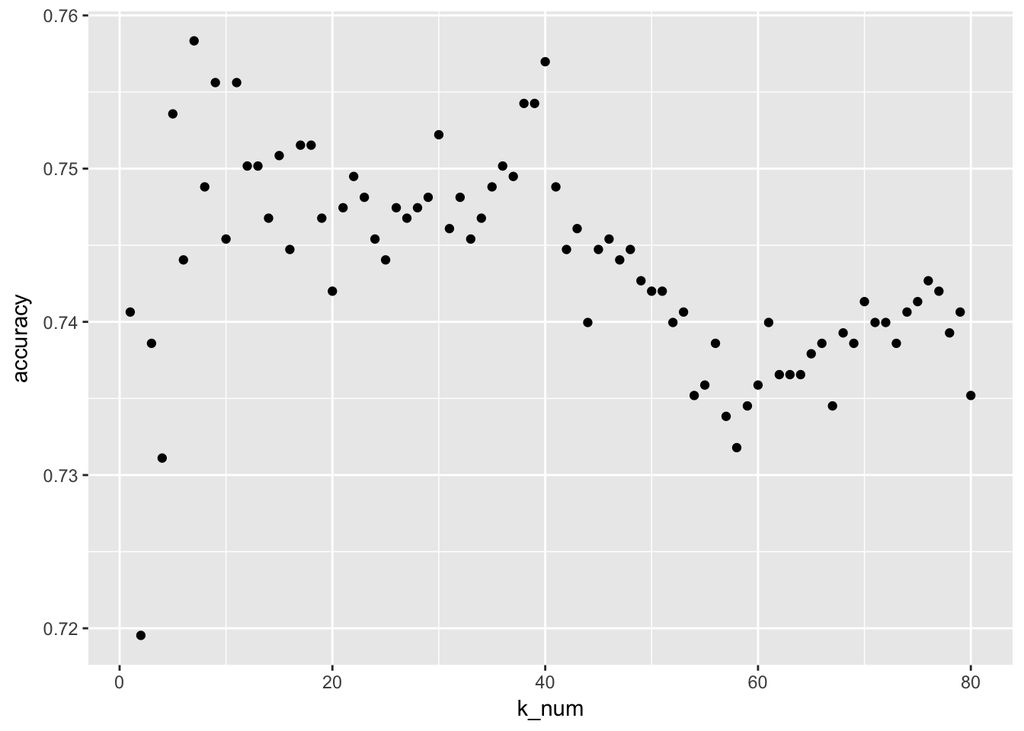

```r
results.train <- ww.train[,13]
results.validate <- ww.validate[,13]
results.test <- ww.test[,13]
results.all <- append(results.train, results.validate, after = length(results.train) + 1)

train.results <- data.frame(matrix(ncol = 80, nrow = length(results.validate)))

# Plot accuracy for models trained with all values of k
# Y axis
accuracy <- c()
for (i in 1:80) {
  knn.pred <- knn(standardized.train, standardized.validate, results.train, k = i)
  knn.pred <- as.vector(knn.pred)
  train.results <- cbind(train.results, knn.pred)
  acc <- sum(knn.pred == results.validate) / length(results.validate)
  accuracy <- c(accuracy, acc)
}
# X axis
k_num <- c(1:80)
accuracy_set <- data.frame(k_number = k_num, accuracy = accuracy)
kplot <- ggplot(accuracy_set, aes(k_num, accuracy)) + geom_point()
kplot
```

```r
# Give columns same name as value of k
train.results <- train.results[,-1:-80]
```

For each k = 1, …, 80, we checked what percentage of the validation samples was correctly classified by plotting accuracy for each value of k. The value of k we want to use is the one that has the best result on the validation set. There are some k that would give us higher percentages of correctly classified samples. However, they are too low which means that there is a possibility that each data point only explains itself. We would choose lower k if the concept is very difficult, but this is not the case. For the optimal k, we checked what percentage of the test samples is correctly classified and that gave us a generalisation error. We looked more closely at different model evaluation measures for the values of k for which the model had high accuracy.

### 6. evaluates each classifier on the validation set and selects the best classifier;

- true negative (0:0), true positive (1:1)
- false positive (1:0), false negative (0:1)

###### Model evaluation for k = 1

```r
knn.1 <- train.results[,1]

# number of correct predictions for each k:
accuracy.knn1 <- sum(results.validate == knn.1)  # For knn = 1
ct.k1 <- CrossTable(x = results.validate, y = knn.1, prop.chisq = FALSE, prop.r = FALSE, prop.t = FALSE, prop.c = FALSE)
```

```
##
##
##    Cell Contents
## |-------------------------|
## |                       N |
## |-------------------------|
##
##
## Total Observations in Table:  1469
##
##
##                  | knn.1
## results.validate |         0 |         1 | Row Total |
## -----------------|-----------|-----------|-----------|
##                0 |       316 |       180 |       496 |
## -----------------|-----------|-----------|-----------|
##                1 |       201 |       772 |       973 |
## -----------------|-----------|-----------|-----------|
##     Column Total |       517 |       952 |      1469 |
## -----------------|-----------|-----------|-----------|
##
##
```

```r
# Sensitivity:
sensitivity.k1 <- (ct.k1$t[2,2])/(ct.k1$t[2,2] + ct.k1$t[2,1])
# Specificity:
specificity.k1 <- (ct.k1$t[1,1])/(ct.k1$t[1,1] + ct.k1$t[1,2])
# Error and accuracy:
error.k1 <- (ct.k1$t[2,1] + ct.k1$t[1,2])/(ct.k1$t[1,1] + ct.k1$t[1,2] + ct.k1$t[2,2] + ct.k1$t[2,1])
accuracy.k1 <- 1 - error.k1
round(sensitivity.k1 * 100, 2) # true yes rate
```

```
## [1] 79.34
```

```r
round(specificity.k1 * 100, 2) # true no rate
```

```
## [1] 63.71
```

```r
round(error.k1 * 100, 2) # error rate
```

```
## [1] 25.94
```

```r
round(accuracy.k1 * 100, 2)
```

```
## [1] 74.06
```

###### Model evaluation for k = 40

```r
knn.40 <- train.results[,40]

# number of correct predictions for each k:
accuracy.knn40 <- sum(results.validate == knn.40)  # For knn = 40
ct.k40 <- CrossTable(x = results.validate, y = knn.40, prop.chisq = FALSE, prop.r = FALSE, prop.t = FALSE, prop.c = FALSE)
```

```
##
##
##    Cell Contents
## |-------------------------|
## |                       N |
## |-------------------------|
##
##
## Total Observations in Table:  1469
##
##
##                  | knn.40
## results.validate |         0 |         1 | Row Total |
## -----------------|-----------|-----------|-----------|
##                0 |       247 |       249 |       496 |
## -----------------|-----------|-----------|-----------|
##                1 |       108 |       865 |       973 |
## -----------------|-----------|-----------|-----------|
##     Column Total |       355 |      1114 |      1469 |
## -----------------|-----------|-----------|-----------|
##
##
```

```r
# Sensitivity:
sensitivity.k40 <- (ct.k40$t[2,2])/(ct.k40$t[2,2] + ct.k40$t[2,1])
# Specificity:
specificity.k40 <- (ct.k40$t[1,1])/(ct.k40$t[1,1] + ct.k40$t[1,2])
# Error and accuracy:
error.k40 <- (ct.k40$t[2,1] + ct.k40$t[1,2])/(ct.k40$t[1,1] + ct.k40$t[1,2] + ct.k40$t[2,2] + ct.k40$t[2,1])
accuracy.k40 <- 1 - error.k40
round(sensitivity.k40 * 100, 2) # true yes
```

```
## [1] 88.9
```

```r
round(specificity.k40 * 100, 2) # true no
```

```
## [1] 49.8
```

```r
round(error.k40 * 100, 2) # error
```

```
## [1] 24.3
```

```r
round(accuracy.k40 * 100, 2)
```

```
## [1] 75.7
```

###### Model evaluation for k = 38

```r
knn.38 <- train.results[,38]

# number of correct predictions for each k:
accuracy.knn38 <- sum(results.validate == knn.38)  # For knn = 38
ct.k38 <- CrossTable(x = results.validate, y = knn.38, prop.chisq = FALSE, prop.r = FALSE, prop.t = FALSE, prop.c = FALSE)
```

```
##
##
##    Cell Contents
## |-------------------------|
## |                       N |
## |-------------------------|
##
##
## Total Observations in Table:  1469
##
##
##                  | knn.38
## results.validate |         0 |         1 | Row Total |
## -----------------|-----------|-----------|-----------|
##                0 |       241 |       255 |       496 |
## -----------------|-----------|-----------|-----------|
##                1 |       106 |       867 |       973 |
## -----------------|-----------|-----------|-----------|
##     Column Total |       347 |      1122 |      1469 |
## -----------------|-----------|-----------|-----------|
##
##
```

```r
# Sensitivity:
sensitivity.k38 <- (ct.k38$t[2,2])/(ct.k38$t[2,2] + ct.k38$t[2,1])
# Specificity:
specificity.k38 <- (ct.k38$t[1,1])/(ct.k38$t[1,1] + ct.k38$t[1,2])
# Error and accuracy:
error.k38 <- (ct.k38$t[2,1] + ct.k38$t[1,2])/(ct.k38$t[1,1] + ct.k38$t[1,2] + ct.k38$t[2,2] + ct.k38$t[2,1])
accuracy.k38 <- 1 - error.k38
round(sensitivity.k38 * 100, 2) # true yes
```

```
## [1] 89.11
```

```r
round(specificity.k38 * 100, 2) # true no
```

```
## [1] 48.59
```

```r
round(error.k38 * 100, 2) # error
```

```
## [1] 24.57
```

```r
round(accuracy.k38 * 100, 2)
```

```
## [1] 75.43
```

###### Model evaluation for k = 39

```r
knn.39 <- train.results[,39]

# number of correct predictions for each k:
accuracy.knn39 <- sum(results.validate == knn.39)  # For knn = 35
ct.k39 <- CrossTable(x = results.validate, y = knn.39, prop.chisq = FALSE, prop.r = FALSE, prop.t = FALSE, prop.c = FALSE)
```

```
##
##
##    Cell Contents
## |-------------------------|
## |                       N |
## |-------------------------|
##
##
## Total Observations in Table:  1469
##
##
##                  | knn.39
## results.validate |         0 |         1 | Row Total |
## -----------------|-----------|-----------|-----------|
##                0 |       248 |       248 |       496 |
## -----------------|-----------|-----------|-----------|
##                1 |       113 |       860 |       973 |
## -----------------|-----------|-----------|-----------|
##     Column Total |       361 |      1108 |      1469 |
## -----------------|-----------|-----------|-----------|
##
##
```

```r
# Sensitivity:
sensitivity.k39 <- (ct.k39$t[2,2])/(ct.k39$t[2,2] + ct.k39$t[2,1])
# Specificity:
specificity.k39 <- (ct.k39$t[1,1])/(ct.k39$t[1,1] + ct.k39$t[1,2])
# Error and accuracy:
error.k39 <- (ct.k39$t[2,1] + ct.k39$t[1,2])/(ct.k39$t[1,1] + ct.k39$t[1,2] + ct.k39$t[2,2] + ct.k39$t[2,1])
accuracy.k39 <- 1 - error.k39
round(sensitivity.k39 * 100, 2) # true yes
```

```
## [1] 88.39
```

```r
round(specificity.k39 * 100, 2) # true no
```

```
## [1] 50
```

```r
round(error.k39 * 100, 2) # error
```

```
## [1] 24.57
```

```r
round(accuracy.k39 * 100, 2)
```

```
## [1] 75.43
```

###### Model evaluation for k = 41

```r
knn.41 <- train.results[,41]

# number of correct predictions for each k:
accuracy.knn41 <- sum(results.validate == knn.41)  # For knn = 41
ct.k41 <- CrossTable(x = results.validate, y = knn.41, prop.chisq = FALSE, prop.r = FALSE, prop.t = FALSE, prop.c = FALSE)
```

```
##
##
##    Cell Contents
## |-------------------------|
## |                       N |
## |-------------------------|
##
##
## Total Observations in Table:  1469
##
##
##                  | knn.41
## results.validate |         0 |         1 | Row Total |
## -----------------|-----------|-----------|-----------|
##                0 |       240 |       256 |       496 |
## -----------------|-----------|-----------|-----------|
##                1 |       113 |       860 |       973 |
## -----------------|-----------|-----------|-----------|
##     Column Total |       353 |      1116 |      1469 |
## -----------------|-----------|-----------|-----------|
##
##
```

```r
# Sensitivity:
sensitivity.k41 <- (ct.k41$t[2,2])/(ct.k41$t[2,2] + ct.k41$t[2,1])
# Specificity:
specificity.k41 <- (ct.k41$t[1,1])/(ct.k41$t[1,1] + ct.k41$t[1,2])
# Error and accuracy:
error.k41 <- (ct.k41$t[2,1] + ct.k41$t[1,2])/(ct.k41$t[1,1] + ct.k41$t[1,2] + ct.k41$t[2,2] + ct.k41$t[2,1])
accuracy.k41 <- 1 - error.k41
round(sensitivity.k41 * 100, 2) # true yes
```

```
## [1] 88.39
```

```r
round(specificity.k41 * 100, 2) # true no
```

```
## [1] 48.39
```

```r
round(error.k41 * 100, 2) # error
```

```
## [1] 25.12
```

```r
round(accuracy.k41 * 100, 2)
```

```
## [1] 74.88
```

- The model with $k=40$ was selected as it gives the best result on the validation set compared to the results of the predicitions with $k = 38$, $k = 39$, and $k = 41$.

### 7. Predicts the generalisation error using the test data set, as well as outputs the result in a confusion matrix.

```r
# Model with k = 40
final.knn <- knn(standardized.ww, standardized.test, results.all, k = 40)

# number of correct predictions for each k:
results.final <- sum(results.test == final.knn)
final.knn <- CrossTable(x = results.test, y = final.knn, prop.chisq = FALSE, prop.r = FALSE, prop.t = FALSE, prop.c = FALSE)
```

```
##
##
##    Cell Contents
## |-------------------------|
## |                       N |
## |-------------------------|
##
##
## Total Observations in Table:  1469
##
##
##              | final.knn
## results.test |         0 |         1 | Row Total |
## -------------|-----------|-----------|-----------|
##            0 |       266 |       235 |       501 |
## -------------|-----------|-----------|-----------|
##            1 |       102 |       866 |       968 |
## -------------|-----------|-----------|-----------|
## Column Total |       368 |      1101 |      1469 |
## -------------|-----------|-----------|-----------|
##
##
```

```r
# Sensitivity:
sensitivity.final <- (final.knn$t[2,2])/(final.knn$t[2,2] + final.knn$t[2,1])

# Specificity:
specificity.final <- (final.knn$t[1,1])/(final.knn$t[1,1] + final.knn$t[1,2])

# Error and accuracy:
error.final <- (final.knn$t[2,1] + final.knn$t[1,2])/(final.knn$t[1,1] + final.knn$t[1,2] + final.knn$t[2,2] + final.knn$t[2,1])

accuracy.final <- 1 - error.final

round(sensitivity.final * 100, 2) # true yes
```

```
## [1] 89.46
```

```r
round(specificity.final * 100, 2) # true no
```

```
## [1] 53.09
```

```r
round(error.final * 100, 2) # error
```

```
## [1] 22.94
```

```r
round(accuracy.final * 100, 2)
```

```
## [1] 77.06
```

### How do you judge whether the classifier is well-suited for the data set?

We should choose k large enough that noise in the data is minimized (and overfitting is avoided) and small enough so the samples of the other classes are not included. Large k converges towards “training average” and underfits the data, while small k reacts to noise/outliers (overfitting). Therefore, we follow the rule of thumb: $k=\sqrt n$ = $\sqrt{1469}$ = $38.33$. However, we chose $k=40$ as the final classifier as it has the highest accuracy (compared to the middle values) on the validation set.